# Risk Factor Analysis

## Outcome Variable

**Outcome Variable:** whz

## Predictor Variables

**Intervention Variable:** impfloor

**Adjustment Set:**

- arm
- sex
- W_mage
- meducyrs
- feducyrs
- hhwealth_quart
- hfoodsec
- W_mhtcm
- W_mwtkg
- W_mbmi
- W_nrooms
- W_nchldlt5
- W_parity
- impsan
- safeh20
- delta_W_mage
- delta_meducyrs
- delta_feducyrs
- delta_hhwealth_quart
- delta_hfoodsec
- delta_W_mhtcm
- delta_W_mwtkg
- delta_W_mbmi
- delta_W_nrooms
- delta_W_nchldlt5
- delta_W_parity
- delta_impsan
- delta_safeh20

## Stratifying Variables

The analysis was stratified on these variable(s):

- agecat
- studyid
- country

## Data Summary

| agecat | studyid | country | impfloor | n_cell | n | outcome_variable |
| --- | --- | --- | --- | --- | --- | --- |
| Birth | CMC-V-BCS-2002 | INDIA | 1 | 68 | 68 | whz |
| Birth | CMC-V-BCS-2002 | INDIA | 0 | 0 | 68 | whz |
| Birth | CONTENT | PERU | 1 | 2 | 2 | whz |
| Birth | CONTENT | PERU | 0 | 0 | 2 | whz |
| Birth | GMS-Nepal | NEPAL | 1 | 97 | 503 | whz |
| Birth | GMS-Nepal | NEPAL | 0 | 406 | 503 | whz |
| Birth | IRC | INDIA | 1 | 253 | 253 | whz |
| Birth | IRC | INDIA | 0 | 0 | 253 | whz |
| Birth | JiVitA-3 | BANGLADESH | 1 | 1215 | 17966 | whz |
| Birth | JiVitA-3 | BANGLADESH | 0 | 16751 | 17966 | whz |
| Birth | JiVitA-4 | BANGLADESH | 1 | 271 | 2394 | whz |
| Birth | JiVitA-4 | BANGLADESH | 0 | 2123 | 2394 | whz |
| Birth | MAL-ED | BANGLADESH | 1 | 185 | 201 | whz |
| Birth | MAL-ED | BANGLADESH | 0 | 16 | 201 | whz |
| Birth | MAL-ED | BRAZIL | 1 | 55 | 57 | whz |
| Birth | MAL-ED | BRAZIL | 0 | 2 | 57 | whz |
| Birth | MAL-ED | INDIA | 1 | 33 | 39 | whz |
| Birth | MAL-ED | INDIA | 0 | 6 | 39 | whz |
| Birth | MAL-ED | NEPAL | 1 | 8 | 24 | whz |
| Birth | MAL-ED | NEPAL | 0 | 16 | 24 | whz |
| Birth | MAL-ED | PERU | 1 | 37 | 210 | whz |
| Birth | MAL-ED | PERU | 0 | 173 | 210 | whz |
| Birth | MAL-ED | SOUTH AFRICA | 1 | 86 | 95 | whz |
| Birth | MAL-ED | SOUTH AFRICA | 0 | 9 | 95 | whz |
| Birth | MAL-ED | TANZANIA, UNITED REPUBLIC OF | 1 | 5 | 111 | whz |
| Birth | MAL-ED | TANZANIA, UNITED REPUBLIC OF | 0 | 106 | 111 | whz |
| Birth | NIH-Birth | BANGLADESH | 1 | 505 | 572 | whz |
| Birth | NIH-Birth | BANGLADESH | 0 | 67 | 572 | whz |
| Birth | NIH-Crypto | BANGLADESH | 1 | 542 | 707 | whz |
| Birth | NIH-Crypto | BANGLADESH | 0 | 165 | 707 | whz |

[output cut: 66 more lines]

The following strata were considered:

- agecat: 24 months, studyid: CMC-V-BCS-2002, country: INDIA
- agecat: 24 months, studyid: CONTENT, country: PERU
- agecat: 24 months, studyid: GMS-Nepal, country: NEPAL
- agecat: 24 months, studyid: IRC, country: INDIA
- agecat: 24 months, studyid: JiVitA-3, country: BANGLADESH
- agecat: 24 months, studyid: JiVitA-4, country: BANGLADESH
- agecat: 24 months, studyid: MAL-ED, country: BANGLADESH
- agecat: 24 months, studyid: MAL-ED, country: BRAZIL
- agecat: 24 months, studyid: MAL-ED, country: INDIA
- agecat: 24 months, studyid: MAL-ED, country: NEPAL
- agecat: 24 months, studyid: MAL-ED, country: PERU
- agecat: 24 months, studyid: MAL-ED, country: SOUTH AFRICA
- agecat: 24 months, studyid: MAL-ED, country: TANZANIA, UNITED REPUBLIC OF
- agecat: 24 months, studyid: NIH-Birth, country: BANGLADESH
- agecat: 24 months, studyid: NIH-Crypto, country: BANGLADESH
- agecat: 24 months, studyid: PROVIDE, country: BANGLADESH
- agecat: 6 months, studyid: CMC-V-BCS-2002, country: INDIA
- agecat: 6 months, studyid: CONTENT, country: PERU
- agecat: 6 months, studyid: GMS-Nepal, country: NEPAL
- agecat: 6 months, studyid: IRC, country: INDIA
- agecat: 6 months, studyid: JiVitA-3, country: BANGLADESH
- agecat: 6 months, studyid: JiVitA-4, country: BANGLADESH
- agecat: 6 months, studyid: MAL-ED, country: BANGLADESH
- agecat: 6 months, studyid: MAL-ED, country: BRAZIL
- agecat: 6 months, studyid: MAL-ED, country: INDIA
- agecat: 6 months, studyid: MAL-ED, country: NEPAL
- agecat: 6 months, studyid: MAL-ED, country: PERU
- agecat: 6 months, studyid: MAL-ED, country: SOUTH AFRICA
- agecat: 6 months, studyid: MAL-ED, country: TANZANIA, UNITED REPUBLIC OF
- agecat: 6 months, studyid: NIH-Birth, country: BANGLADESH
- agecat: 6 months, studyid: NIH-Crypto, country: BANGLADESH
- agecat: 6 months, studyid: PROVIDE, country: BANGLADESH
- agecat: Birth, studyid: CMC-V-BCS-2002, country: INDIA
- agecat: Birth, studyid: CONTENT, country: PERU
- agecat: Birth, studyid: GMS-Nepal, country: NEPAL
- agecat: Birth, studyid: IRC, country: INDIA
- agecat: Birth, studyid: JiVitA-3, country: BANGLADESH
- agecat: Birth, studyid: JiVitA-4, country: BANGLADESH
- agecat: Birth, studyid: MAL-ED, country: BANGLADESH
- agecat: Birth, studyid: MAL-ED, country: BRAZIL
- agecat: Birth, studyid: MAL-ED, country: INDIA
- agecat: Birth, studyid: MAL-ED, country: NEPAL
- agecat: Birth, studyid: MAL-ED, country: PERU
- agecat: Birth, studyid: MAL-ED, country: SOUTH AFRICA
- agecat: Birth, studyid: MAL-ED, country: TANZANIA, UNITED REPUBLIC OF
- agecat: Birth, studyid: NIH-Birth, country: BANGLADESH
- agecat: Birth, studyid: NIH-Crypto, country: BANGLADESH
- agecat: Birth, studyid: PROVIDE, country: BANGLADESH

### Dropped Strata

- agecat: Birth, studyid: CMC-V-BCS-2002, country: INDIA
- agecat: Birth, studyid: CONTENT, country: PERU
- agecat: Birth, studyid: IRC, country: INDIA
- agecat: Birth, studyid: MAL-ED, country: BRAZIL
- agecat: 6 months, studyid: CMC-V-BCS-2002, country: INDIA
- agecat: 6 months, studyid: IRC, country: INDIA
- agecat: 6 months, studyid: MAL-ED, country: BRAZIL
- agecat: 24 months, studyid: CMC-V-BCS-2002, country: INDIA
- agecat: 24 months, studyid: IRC, country: INDIA
- agecat: 24 months, studyid: MAL-ED, country: BRAZIL

## Methods Detail

We’re interested in the causal parameters $E[Y_a]$ for all values of $a \in \mathcal{A}$. These parameters represent the mean outcome if, possibly contrary to fact, we intervened to set all units to have $A=a$. Under the randomization and positivity assumptions, these are identified by the statistical parameters $\psi_a=E_W[E_{Y|A,W}(Y|A=a,W)]$. In addition, we’re interested in the mean of $Y$, $E[Y]$ under no intervention (the observed mean). We will estimate these parameters by using SuperLearner to fit the relevant likelihood factors – $E_{Y|A,W}(Y|A=a,W)$ and $p(A=a|W)$, and then updating our likelihood fit using a joint TMLE.

For unadjusted analyses ($W=\{\}$), initial likelihoods were estimated using Lrnr_glm to estimate the simple $E(Y|A)$ and Lrnr_mean to estimate $p(A)$. For adjusted analyses, a small library containing Lrnr_glmnet, Lrnr_xgboost, and Lrnr_mean was used.

Having estimated these parameters, we will then use the delta method to estimate relative risks and attributable risks relative to a prespecified baseline level of $A$.

# Results Detail

## Results Plots

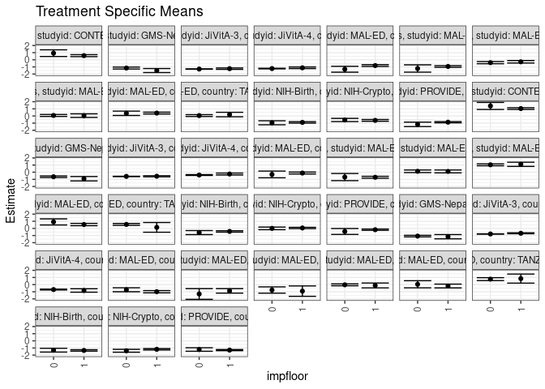

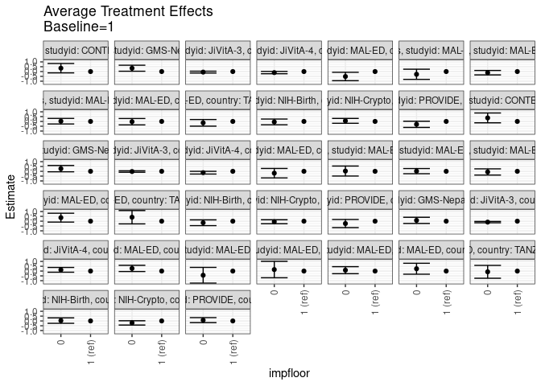

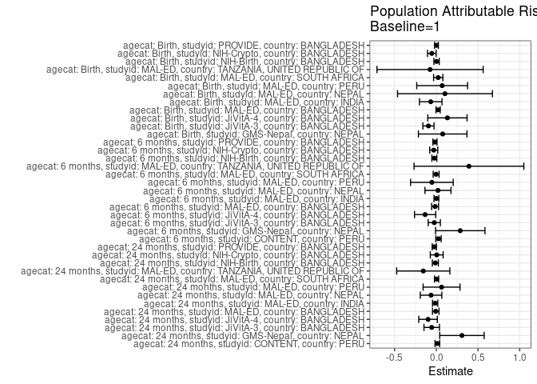

## Results Table

### Parameter: TSM

| agecat | studyid | country | intervention_level | baseline_level | estimate | ci_lower | ci_upper |
| --- | --- | --- | --- | --- | --- | --- | --- |
| Birth | GMS-Nepal | NEPAL | 1 | NA | -1.1625774 | -1.4623357 | -0.8628192 |
| Birth | GMS-Nepal | NEPAL | 0 | NA | -1.0784433 | -1.1898254 | -0.9670612 |
| Birth | JiVitA-3 | BANGLADESH | 1 | NA | -0.6831671 | -0.7511870 | -0.6151473 |
| Birth | JiVitA-3 | BANGLADESH | 0 | NA | -0.7797182 | -0.7999139 | -0.7595225 |
| Birth | JiVitA-4 | BANGLADESH | 1 | NA | -0.8215955 | -1.0640495 | -0.5791416 |
| Birth | JiVitA-4 | BANGLADESH | 0 | NA | -0.6935117 | -0.7507107 | -0.6363128 |
| Birth | MAL-ED | BANGLADESH | 1 | NA | -0.9942321 | -1.1538370 | -0.8346271 |
| Birth | MAL-ED | BANGLADESH | 0 | NA | -0.7200658 | -0.9986107 | -0.4415209 |
| Birth | MAL-ED | INDIA | 1 | NA | -0.8772727 | -1.1935310 | -0.5610144 |
| Birth | MAL-ED | INDIA | 0 | NA | -1.3116667 | -2.0623390 | -0.5609943 |
| Birth | MAL-ED | NEPAL | 1 | NA | -0.9125000 | -1.6413488 | -0.1836512 |
| Birth | MAL-ED | NEPAL | 0 | NA | -0.7568750 | -1.1980753 | -0.3156747 |
| Birth | MAL-ED | PERU | 1 | NA | -0.1170407 | -0.4575450 | 0.2234636 |
| Birth | MAL-ED | PERU | 0 | NA | -0.0255348 | -0.1605940 | 0.1095243 |
| Birth | MAL-ED | SOUTH AFRICA | 1 | NA | -0.1959302 | -0.4617510 | 0.0698905 |
| Birth | MAL-ED | SOUTH AFRICA | 0 | NA | 0.0466667 | -0.4532880 | 0.5466213 |
| Birth | MAL-ED | TANZANIA, UNITED REPUBLIC OF | 1 | NA | 0.8440000 | 0.2094403 | 1.4785597 |
| Birth | MAL-ED | TANZANIA, UNITED REPUBLIC OF | 0 | NA | 0.7655660 | 0.5608207 | 0.9703114 |
| Birth | NIH-Birth | BANGLADESH | 1 | NA | -1.3479139 | -1.4492652 | -1.2465627 |
| Birth | NIH-Birth | BANGLADESH | 0 | NA | -1.3114627 | -1.5750179 | -1.0479076 |
| Birth | NIH-Crypto | BANGLADESH | 1 | NA | -1.1902992 | -1.2865105 | -1.0940879 |
| Birth | NIH-Crypto | BANGLADESH | 0 | NA | -1.3933869 | -1.5936522 | -1.1931215 |
| Birth | PROVIDE | BANGLADESH | 1 | NA | -1.2999286 | -1.3805052 | -1.2193520 |
| Birth | PROVIDE | BANGLADESH | 0 | NA | -1.2168165 | -1.4642341 | -0.9693990 |
| 6 months | CONTENT | PERU | 1 | NA | 1.0382357 | 0.9166736 | 1.1597979 |
| 6 months | CONTENT | PERU | 0 | NA | 1.4033141 | 0.9096438 | 1.8969843 |
| 6 months | GMS-Nepal | NEPAL | 1 | NA | -0.9143597 | -1.2217066 | -0.6070129 |
| 6 months | GMS-Nepal | NEPAL | 0 | NA | -0.6387458 | -0.7499425 | -0.5275492 |
| 6 months | JiVitA-3 | BANGLADESH | 1 | NA | -0.5680733 | -0.6413845 | -0.4947621 |
| 6 months | JiVitA-3 | BANGLADESH | 0 | NA | -0.5902167 | -0.6122716 | -0.5681619 |
| 6 months | JiVitA-4 | BANGLADESH | 1 | NA | -0.2556729 | -0.3860891 | -0.1252567 |
| 6 months | JiVitA-4 | BANGLADESH | 0 | NA | -0.3978394 | -0.4552020 | -0.3404769 |
| 6 months | MAL-ED | BANGLADESH | 1 | NA | -0.1190913 | -0.2533201 | 0.0151376 |
| 6 months | MAL-ED | BANGLADESH | 0 | NA | -0.3133134 | -0.7834663 | 0.1568394 |
| 6 months | MAL-ED | INDIA | 1 | NA | -0.7112711 | -0.8448879 | -0.5776544 |
| 6 months | MAL-ED | INDIA | 0 | NA | -0.6832983 | -1.1846780 | -0.1819186 |
| 6 months | MAL-ED | NEPAL | 1 | NA | 0.1080652 | -0.0925405 | 0.3086709 |
| 6 months | MAL-ED | NEPAL | 0 | NA | 0.1260422 | -0.0534659 | 0.3055502 |
| 6 months | MAL-ED | PERU | 1 | NA | 1.1040658 | 0.8111684 | 1.3969631 |
| 6 months | MAL-ED | PERU | 0 | NA | 1.0368964 | 0.9012263 | 1.1725664 |
| 6 months | MAL-ED | SOUTH AFRICA | 1 | NA | 0.5427929 | 0.3792324 | 0.7063535 |
| 6 months | MAL-ED | SOUTH AFRICA | 0 | NA | 0.9092687 | 0.4817756 | 1.3367619 |
| 6 months | MAL-ED | TANZANIA, UNITED REPUBLIC OF | 1 | NA | 0.1446322 | -0.5351962 | 0.8244606 |
| 6 months | MAL-ED | TANZANIA, UNITED REPUBLIC OF | 0 | NA | 0.5574496 | 0.4224292 | 0.6924700 |
| 6 months | NIH-Birth | BANGLADESH | 1 | NA | -0.4211362 | -0.5175093 | -0.3247632 |
| 6 months | NIH-Birth | BANGLADESH | 0 | NA | -0.5833798 | -0.8654524 | -0.3013072 |
| 6 months | NIH-Crypto | BANGLADESH | 1 | NA | 0.0605841 | -0.0312298 | 0.1523980 |
| 6 months | NIH-Crypto | BANGLADESH | 0 | NA | 0.0034295 | -0.1810140 | 0.1878730 |
| 6 months | PROVIDE | BANGLADESH | 1 | NA | -0.1828469 | -0.2703947 | -0.0952991 |
| 6 months | PROVIDE | BANGLADESH | 0 | NA | -0.4281027 | -0.8423852 | -0.0138201 |
| 24 months | CONTENT | PERU | 1 | NA | 0.5777631 | 0.4375518 | 0.7179743 |
| 24 months | CONTENT | PERU | 0 | NA | 0.9268888 | 0.4609271 | 1.3928504 |
| 24 months | GMS-Nepal | NEPAL | 1 | NA | -1.5063486 | -1.7864976 | -1.2261995 |
| 24 months | GMS-Nepal | NEPAL | 0 | NA | -1.1595891 | -1.2958508 | -1.0233273 |
| 24 months | JiVitA-3 | BANGLADESH | 1 | NA | -1.2419047 | -1.3386424 | -1.1451670 |
| 24 months | JiVitA-3 | BANGLADESH | 0 | NA | -1.2997995 | -1.3247892 | -1.2748097 |
| 24 months | JiVitA-4 | BANGLADESH | 1 | NA | -1.1242547 | -1.2367379 | -1.0117715 |
| 24 months | JiVitA-4 | BANGLADESH | 0 | NA | -1.2320545 | -1.2727310 | -1.1913781 |
| 24 months | MAL-ED | BANGLADESH | 1 | NA | -0.8126310 | -0.9389417 | -0.6863202 |
| 24 months | MAL-ED | BANGLADESH | 0 | NA | -1.3273195 | -1.7387056 | -0.9159335 |
| 24 months | MAL-ED | INDIA | 1 | NA | -0.9374963 | -1.0581820 | -0.8168106 |
| 24 months | MAL-ED | INDIA | 0 | NA | -1.2228883 | -1.7366015 | -0.7091752 |
| 24 months | MAL-ED | NEPAL | 1 | NA | -0.2839346 | -0.4571829 | -0.1106863 |
| 24 months | MAL-ED | NEPAL | 0 | NA | -0.4013712 | -0.5534510 | -0.2492914 |
| 24 months | MAL-ED | PERU | 1 | NA | 0.0482406 | -0.2041488 | 0.3006301 |
| 24 months | MAL-ED | PERU | 0 | NA | 0.0735853 | -0.0661641 | 0.2133348 |
| 24 months | MAL-ED | SOUTH AFRICA | 1 | NA | 0.4062553 | 0.2772174 | 0.5352931 |
| 24 months | MAL-ED | SOUTH AFRICA | 0 | NA | 0.3775116 | 0.0737809 | 0.6812422 |
| 24 months | MAL-ED | TANZANIA, UNITED REPUBLIC OF | 1 | NA | 0.2042031 | -0.1094616 | 0.5178677 |
| 24 months | MAL-ED | TANZANIA, UNITED REPUBLIC OF | 0 | NA | 0.0570344 | -0.0745055 | 0.1885743 |
| 24 months | NIH-Birth | BANGLADESH | 1 | NA | -0.8991973 | -1.0037473 | -0.7946474 |
| 24 months | NIH-Birth | BANGLADESH | 0 | NA | -0.9510963 | -1.2293381 | -0.6728545 |
| 24 months | NIH-Crypto | BANGLADESH | 1 | NA | -0.6151352 | -0.7375006 | -0.4927699 |
| 24 months | NIH-Crypto | BANGLADESH | 0 | NA | -0.5560730 | -0.7770593 | -0.3350867 |
| 24 months | PROVIDE | BANGLADESH | 1 | NA | -0.8688300 | -0.9547208 | -0.7829392 |
| 24 months | PROVIDE | BANGLADESH | 0 | NA | -1.1702452 | -1.4812016 | -0.8592888 |

### Parameter: E(Y)

| agecat | studyid | country | intervention_level | baseline_level | estimate | ci_lower | ci_upper |
| --- | --- | --- | --- | --- | --- | --- | --- |
| Birth | GMS-Nepal | NEPAL | NA | NA | -1.0860636 | -1.1830454 | -0.9890818 |
| Birth | JiVitA-3 | BANGLADESH | NA | NA | -0.7773511 | -0.7963777 | -0.7583245 |
| Birth | JiVitA-4 | BANGLADESH | NA | NA | -0.6882498 | -0.7406539 | -0.6358456 |
| Birth | MAL-ED | BANGLADESH | NA | NA | -0.9728358 | -1.1217009 | -0.8239707 |
| Birth | MAL-ED | INDIA | NA | NA | -0.9441026 | -1.2397919 | -0.6484132 |
| Birth | MAL-ED | NEPAL | NA | NA | -0.8087500 | -1.1914221 | -0.4260779 |
| Birth | MAL-ED | PERU | NA | NA | -0.0468095 | -0.1738806 | 0.0802616 |
| Birth | MAL-ED | SOUTH AFRICA | NA | NA | -0.1729474 | -0.4186222 | 0.0727275 |
| Birth | MAL-ED | TANZANIA, UNITED REPUBLIC OF | NA | NA | 0.7690991 | 0.5714748 | 0.9667234 |
| Birth | NIH-Birth | BANGLADESH | NA | NA | -1.3448514 | -1.4396716 | -1.2500312 |
| Birth | NIH-Crypto | BANGLADESH | NA | NA | -1.2441513 | -1.3281130 | -1.1601897 |
| Birth | PROVIDE | BANGLADESH | NA | NA | -1.2984586 | -1.3752758 | -1.2216415 |
| 6 months | CONTENT | PERU | NA | NA | 1.0644279 | 0.9468682 | 1.1819876 |
| 6 months | GMS-Nepal | NEPAL | NA | NA | -0.6273772 | -0.7253868 | -0.5293676 |
| 6 months | JiVitA-3 | BANGLADESH | NA | NA | -0.5926720 | -0.6122891 | -0.5730549 |
| 6 months | JiVitA-4 | BANGLADESH | NA | NA | -0.3901347 | -0.4273932 | -0.3528762 |
| 6 months | MAL-ED | BANGLADESH | NA | NA | -0.1333333 | -0.2623761 | -0.0042906 |
| 6 months | MAL-ED | INDIA | NA | NA | -0.7102872 | -0.8371659 | -0.5834085 |
| 6 months | MAL-ED | NEPAL | NA | NA | 0.1281441 | -0.0056126 | 0.2619008 |
| 6 months | MAL-ED | PERU | NA | NA | 1.0512099 | 0.9285617 | 1.1738581 |
| 6 months | MAL-ED | SOUTH AFRICA | NA | NA | 0.5404351 | 0.3867005 | 0.6941696 |
| 6 months | MAL-ED | TANZANIA, UNITED REPUBLIC OF | NA | NA | 0.5355782 | 0.4032519 | 0.6679046 |
| 6 months | NIH-Birth | BANGLADESH | NA | NA | -0.4447399 | -0.5354039 | -0.3540758 |
| 6 months | NIH-Crypto | BANGLADESH | NA | NA | 0.0297622 | -0.0491685 | 0.1086930 |
| 6 months | PROVIDE | BANGLADESH | NA | NA | -0.1990907 | -0.2817968 | -0.1163845 |
| 24 months | CONTENT | PERU | NA | NA | 0.5902439 | 0.4560143 | 0.7244735 |
| 24 months | GMS-Nepal | NEPAL | NA | NA | -1.1990840 | -1.3039914 | -1.0941766 |
| 24 months | JiVitA-3 | BANGLADESH | NA | NA | -1.2970420 | -1.3203145 | -1.2737694 |
| 24 months | JiVitA-4 | BANGLADESH | NA | NA | -1.2232311 | -1.2550891 | -1.1913732 |
| 24 months | MAL-ED | BANGLADESH | NA | NA | -0.8192925 | -0.9412667 | -0.6973182 |
| 24 months | MAL-ED | INDIA | NA | NA | -0.9516520 | -1.0670654 | -0.8362385 |
| 24 months | MAL-ED | NEPAL | NA | NA | -0.3471493 | -0.4618867 | -0.2324120 |
| 24 months | MAL-ED | PERU | NA | NA | 0.1111982 | -0.0118399 | 0.2342362 |
| 24 months | MAL-ED | SOUTH AFRICA | NA | NA | 0.4090301 | 0.2879441 | 0.5301161 |
| 24 months | MAL-ED | TANZANIA, UNITED REPUBLIC OF | NA | NA | 0.0477437 | -0.0779935 | 0.1734809 |
| 24 months | NIH-Birth | BANGLADESH | NA | NA | -0.9106710 | -1.0090143 | -0.8123277 |
| 24 months | NIH-Crypto | BANGLADESH | NA | NA | -0.6103502 | -0.7050157 | -0.5156847 |
| 24 months | PROVIDE | BANGLADESH | NA | NA | -0.8928670 | -0.9755153 | -0.8102187 |

### Parameter: ATE

| agecat | studyid | country | intervention_level | baseline_level | estimate | ci_lower | ci_upper |
| --- | --- | --- | --- | --- | --- | --- | --- |
| Birth | GMS-Nepal | NEPAL | 1 | 1 | 0.0000000 | 0.0000000 | 0.0000000 |
| Birth | GMS-Nepal | NEPAL | 0 | 1 | 0.0841341 | -0.2355577 | 0.4038259 |
| Birth | JiVitA-3 | BANGLADESH | 1 | 1 | 0.0000000 | 0.0000000 | 0.0000000 |
| Birth | JiVitA-3 | BANGLADESH | 0 | 1 | -0.0965510 | -0.1671145 | -0.0259876 |
| Birth | JiVitA-4 | BANGLADESH | 1 | 1 | 0.0000000 | 0.0000000 | 0.0000000 |
| Birth | JiVitA-4 | BANGLADESH | 0 | 1 | 0.1280838 | -0.1196124 | 0.3757800 |
| Birth | MAL-ED | BANGLADESH | 1 | 1 | 0.0000000 | 0.0000000 | 0.0000000 |
| Birth | MAL-ED | BANGLADESH | 0 | 1 | 0.2741663 | -0.0469822 | 0.5953148 |
| Birth | MAL-ED | INDIA | 1 | 1 | 0.0000000 | 0.0000000 | 0.0000000 |
| Birth | MAL-ED | INDIA | 0 | 1 | -0.4343939 | -1.2489664 | 0.3801785 |
| Birth | MAL-ED | NEPAL | 1 | 1 | 0.0000000 | 0.0000000 | 0.0000000 |
| Birth | MAL-ED | NEPAL | 0 | 1 | 0.1556250 | -0.6963599 | 1.0076099 |
| Birth | MAL-ED | PERU | 1 | 1 | 0.0000000 | 0.0000000 | 0.0000000 |
| Birth | MAL-ED | PERU | 0 | 1 | 0.0915059 | -0.2728750 | 0.4558868 |
| Birth | MAL-ED | SOUTH AFRICA | 1 | 1 | 0.0000000 | 0.0000000 | 0.0000000 |
| Birth | MAL-ED | SOUTH AFRICA | 0 | 1 | 0.2425969 | -0.3236321 | 0.8088259 |
| Birth | MAL-ED | TANZANIA, UNITED REPUBLIC OF | 1 | 1 | 0.0000000 | 0.0000000 | 0.0000000 |
| Birth | MAL-ED | TANZANIA, UNITED REPUBLIC OF | 0 | 1 | -0.0784340 | -0.7452073 | 0.5883394 |
| Birth | NIH-Birth | BANGLADESH | 1 | 1 | 0.0000000 | 0.0000000 | 0.0000000 |
| Birth | NIH-Birth | BANGLADESH | 0 | 1 | 0.0364512 | -0.2459237 | 0.3188261 |
| Birth | NIH-Crypto | BANGLADESH | 1 | 1 | 0.0000000 | 0.0000000 | 0.0000000 |
| Birth | NIH-Crypto | BANGLADESH | 0 | 1 | -0.2030877 | -0.4255638 | 0.0193884 |
| Birth | PROVIDE | BANGLADESH | 1 | 1 | 0.0000000 | 0.0000000 | 0.0000000 |
| Birth | PROVIDE | BANGLADESH | 0 | 1 | 0.0831121 | -0.1763314 | 0.3425556 |
| 6 months | CONTENT | PERU | 1 | 1 | 0.0000000 | 0.0000000 | 0.0000000 |
| 6 months | CONTENT | PERU | 0 | 1 | 0.3650783 | -0.1446985 | 0.8748551 |
| 6 months | GMS-Nepal | NEPAL | 1 | 1 | 0.0000000 | 0.0000000 | 0.0000000 |
| 6 months | GMS-Nepal | NEPAL | 0 | 1 | 0.2756139 | -0.0516328 | 0.6028606 |
| 6 months | JiVitA-3 | BANGLADESH | 1 | 1 | 0.0000000 | 0.0000000 | 0.0000000 |
| 6 months | JiVitA-3 | BANGLADESH | 0 | 1 | -0.0221435 | -0.0986598 | 0.0543729 |
| 6 months | JiVitA-4 | BANGLADESH | 1 | 1 | 0.0000000 | 0.0000000 | 0.0000000 |
| 6 months | JiVitA-4 | BANGLADESH | 0 | 1 | -0.1421665 | -0.2838556 | -0.0004775 |
| 6 months | MAL-ED | BANGLADESH | 1 | 1 | 0.0000000 | 0.0000000 | 0.0000000 |
| 6 months | MAL-ED | BANGLADESH | 0 | 1 | -0.1942222 | -0.6850064 | 0.2965620 |
| 6 months | MAL-ED | INDIA | 1 | 1 | 0.0000000 | 0.0000000 | 0.0000000 |
| 6 months | MAL-ED | INDIA | 0 | 1 | 0.0279728 | -0.4913807 | 0.5473264 |
| 6 months | MAL-ED | NEPAL | 1 | 1 | 0.0000000 | 0.0000000 | 0.0000000 |
| 6 months | MAL-ED | NEPAL | 0 | 1 | 0.0179770 | -0.2509668 | 0.2869208 |
| 6 months | MAL-ED | PERU | 1 | 1 | 0.0000000 | 0.0000000 | 0.0000000 |
| 6 months | MAL-ED | PERU | 0 | 1 | -0.0671694 | -0.3901771 | 0.2558382 |
| 6 months | MAL-ED | SOUTH AFRICA | 1 | 1 | 0.0000000 | 0.0000000 | 0.0000000 |
| 6 months | MAL-ED | SOUTH AFRICA | 0 | 1 | 0.3664758 | -0.0924658 | 0.8254173 |
| 6 months | MAL-ED | TANZANIA, UNITED REPUBLIC OF | 1 | 1 | 0.0000000 | 0.0000000 | 0.0000000 |
| 6 months | MAL-ED | TANZANIA, UNITED REPUBLIC OF | 0 | 1 | 0.4128173 | -0.2800059 | 1.1056406 |
| 6 months | NIH-Birth | BANGLADESH | 1 | 1 | 0.0000000 | 0.0000000 | 0.0000000 |
| 6 months | NIH-Birth | BANGLADESH | 0 | 1 | -0.1622436 | -0.4611211 | 0.1366340 |
| 6 months | NIH-Crypto | BANGLADESH | 1 | 1 | 0.0000000 | 0.0000000 | 0.0000000 |
| 6 months | NIH-Crypto | BANGLADESH | 0 | 1 | -0.0571546 | -0.2628389 | 0.1485297 |
| 6 months | PROVIDE | BANGLADESH | 1 | 1 | 0.0000000 | 0.0000000 | 0.0000000 |
| 6 months | PROVIDE | BANGLADESH | 0 | 1 | -0.2452557 | -0.6694974 | 0.1789859 |
| 24 months | CONTENT | PERU | 1 | 1 | 0.0000000 | 0.0000000 | 0.0000000 |
| 24 months | CONTENT | PERU | 0 | 1 | 0.3491257 | -0.1371016 | 0.8353529 |
| 24 months | GMS-Nepal | NEPAL | 1 | 1 | 0.0000000 | 0.0000000 | 0.0000000 |
| 24 months | GMS-Nepal | NEPAL | 0 | 1 | 0.3467595 | 0.0349899 | 0.6585291 |
| 24 months | JiVitA-3 | BANGLADESH | 1 | 1 | 0.0000000 | 0.0000000 | 0.0000000 |
| 24 months | JiVitA-3 | BANGLADESH | 0 | 1 | -0.0578948 | -0.1548994 | 0.0391098 |
| 24 months | JiVitA-4 | BANGLADESH | 1 | 1 | 0.0000000 | 0.0000000 | 0.0000000 |
| 24 months | JiVitA-4 | BANGLADESH | 0 | 1 | -0.1077998 | -0.2267422 | 0.0111426 |
| 24 months | MAL-ED | BANGLADESH | 1 | 1 | 0.0000000 | 0.0000000 | 0.0000000 |
| 24 months | MAL-ED | BANGLADESH | 0 | 1 | -0.5146886 | -0.9495305 | -0.0798466 |
| 24 months | MAL-ED | INDIA | 1 | 1 | 0.0000000 | 0.0000000 | 0.0000000 |
| 24 months | MAL-ED | INDIA | 0 | 1 | -0.2853920 | -0.8131237 | 0.2423397 |
| 24 months | MAL-ED | NEPAL | 1 | 1 | 0.0000000 | 0.0000000 | 0.0000000 |
| 24 months | MAL-ED | NEPAL | 0 | 1 | -0.1174366 | -0.3477891 | 0.1129159 |
| 24 months | MAL-ED | PERU | 1 | 1 | 0.0000000 | 0.0000000 | 0.0000000 |
| 24 months | MAL-ED | PERU | 0 | 1 | 0.0253447 | -0.2641708 | 0.3148602 |
| 24 months | MAL-ED | SOUTH AFRICA | 1 | 1 | 0.0000000 | 0.0000000 | 0.0000000 |
| 24 months | MAL-ED | SOUTH AFRICA | 0 | 1 | -0.0287437 | -0.3611654 | 0.3036780 |
| 24 months | MAL-ED | TANZANIA, UNITED REPUBLIC OF | 1 | 1 | 0.0000000 | 0.0000000 | 0.0000000 |
| 24 months | MAL-ED | TANZANIA, UNITED REPUBLIC OF | 0 | 1 | -0.1471687 | -0.4901548 | 0.1958175 |
| 24 months | NIH-Birth | BANGLADESH | 1 | 1 | 0.0000000 | 0.0000000 | 0.0000000 |
| 24 months | NIH-Birth | BANGLADESH | 0 | 1 | -0.0518989 | -0.3502464 | 0.2464485 |
| 24 months | NIH-Crypto | BANGLADESH | 1 | 1 | 0.0000000 | 0.0000000 | 0.0000000 |
| 24 months | NIH-Crypto | BANGLADESH | 0 | 1 | 0.0590622 | -0.1919183 | 0.3100427 |
| 24 months | PROVIDE | BANGLADESH | 1 | 1 | 0.0000000 | 0.0000000 | 0.0000000 |
| 24 months | PROVIDE | BANGLADESH | 0 | 1 | -0.3014152 | -0.6240178 | 0.0211874 |

### Parameter: PAR

| agecat | studyid | country | intervention_level | baseline_level | estimate | ci_lower | ci_upper |
| --- | --- | --- | --- | --- | --- | --- | --- |
| Birth | GMS-Nepal | NEPAL | 1 | NA | 0.0765138 | -0.2147043 | 0.3677319 |
| Birth | JiVitA-3 | BANGLADESH | 1 | NA | -0.0941840 | -0.1611058 | -0.0272621 |
| Birth | JiVitA-4 | BANGLADESH | 1 | NA | 0.1333457 | -0.1021040 | 0.3687954 |
| Birth | MAL-ED | BANGLADESH | 1 | NA | 0.0213962 | -0.0042114 | 0.0470039 |
| Birth | MAL-ED | INDIA | 1 | NA | -0.0668298 | -0.2016929 | 0.0680332 |
| Birth | MAL-ED | NEPAL | 1 | NA | 0.1037500 | -0.4650307 | 0.6725307 |
| Birth | MAL-ED | PERU | 1 | NA | 0.0702312 | -0.2346559 | 0.3751183 |
| Birth | MAL-ED | SOUTH AFRICA | 1 | NA | 0.0229829 | -0.0325492 | 0.0785150 |
| Birth | MAL-ED | TANZANIA, UNITED REPUBLIC OF | 1 | NA | -0.0749009 | -0.7116467 | 0.5618449 |
| Birth | NIH-Birth | BANGLADESH | 1 | NA | 0.0030626 | -0.0289647 | 0.0350898 |
| Birth | NIH-Crypto | BANGLADESH | 1 | NA | -0.0538522 | -0.1055783 | -0.0021260 |
| Birth | PROVIDE | BANGLADESH | 1 | NA | 0.0014700 | -0.0215187 | 0.0244586 |
| 6 months | CONTENT | PERU | 1 | NA | 0.0261922 | -0.0059551 | 0.0583394 |
| 6 months | GMS-Nepal | NEPAL | 1 | NA | 0.2869826 | -0.0092716 | 0.5832367 |
| 6 months | JiVitA-3 | BANGLADESH | 1 | NA | -0.0245987 | -0.0974697 | 0.0482723 |
| 6 months | JiVitA-4 | BANGLADESH | 1 | NA | -0.1344618 | -0.2615164 | -0.0074072 |
| 6 months | MAL-ED | BANGLADESH | 1 | NA | -0.0142421 | -0.0552105 | 0.0267263 |
| 6 months | MAL-ED | INDIA | 1 | NA | 0.0009839 | -0.0279461 | 0.0299140 |
| 6 months | MAL-ED | NEPAL | 1 | NA | 0.0200789 | -0.1362554 | 0.1764131 |
| 6 months | MAL-ED | PERU | 1 | NA | -0.0528559 | -0.3083250 | 0.2026132 |
| 6 months | MAL-ED | SOUTH AFRICA | 1 | NA | -0.0023579 | -0.0375382 | 0.0328224 |
| 6 months | MAL-ED | TANZANIA, UNITED REPUBLIC OF | 1 | NA | 0.3909460 | -0.2672214 | 1.0491134 |
| 6 months | NIH-Birth | BANGLADESH | 1 | NA | -0.0236036 | -0.0533159 | 0.0061086 |
| 6 months | NIH-Crypto | BANGLADESH | 1 | NA | -0.0308218 | -0.0789618 | 0.0173181 |
| 6 months | PROVIDE | BANGLADESH | 1 | NA | -0.0162437 | -0.0405925 | 0.0081050 |
| 24 months | CONTENT | PERU | 1 | NA | 0.0124808 | -0.0156370 | 0.0405986 |
| 24 months | GMS-Nepal | NEPAL | 1 | NA | 0.3072646 | 0.0410178 | 0.5735113 |
| 24 months | JiVitA-3 | BANGLADESH | 1 | NA | -0.0551373 | -0.1480773 | 0.0378027 |
| 24 months | JiVitA-4 | BANGLADESH | 1 | NA | -0.0989764 | -0.2103123 | 0.0123595 |
| 24 months | MAL-ED | BANGLADESH | 1 | NA | -0.0066615 | -0.0458538 | 0.0325308 |
| 24 months | MAL-ED | INDIA | 1 | NA | -0.0141557 | -0.0457271 | 0.0174158 |
| 24 months | MAL-ED | NEPAL | 1 | NA | -0.0632147 | -0.1923229 | 0.0658934 |
| 24 months | MAL-ED | PERU | 1 | NA | 0.0629575 | -0.1582158 | 0.2841309 |
| 24 months | MAL-ED | SOUTH AFRICA | 1 | NA | 0.0027748 | -0.0223745 | 0.0279242 |
| 24 months | MAL-ED | TANZANIA, UNITED REPUBLIC OF | 1 | NA | -0.1564594 | -0.4752083 | 0.1622896 |
| 24 months | NIH-Birth | BANGLADESH | 1 | NA | -0.0114736 | -0.0473620 | 0.0244147 |
| 24 months | NIH-Crypto | BANGLADESH | 1 | NA | 0.0047850 | -0.0721225 | 0.0816925 |
| 24 months | PROVIDE | BANGLADESH | 1 | NA | -0.0240371 | -0.0491060 | 0.0010319 |